# PAI Walkthrough

Updated April 2024

## **Predictions as Inference**

```r
pai <- function(data,
                model = NULL,
                outcome = NULL,
                predictors = NULL,
                interactions = NULL,
                drop_vars = NULL,
                cores = NULL,
                placebo_iterations = NULL,
                folds = NULL,
                train_split = 0.8,
                custom_tc = FALSE,
                assign_factors = 3,
                list_drop_vars = FALSE,
                seed = 1234){...}
```

### **Variables**

- `data` Data object
- `model` Model selected from `caret` CRAN (Ex: ‘parRF’, ‘adaboost’)
- `outcome` Dependent variable of interest
- `predictors` Predictors of interest (defaults to all variables in `data` except `outcome`.)
- `interactions` Interaction term(s) declared as a vector separated by ‘,’ (Ex: c(‘var1*var2’, ‘var3:var4’))
- `drop_vars` Specific variables to drop during omission procedure (defaults to all predictors and interactions)
- `cores` Number of computing cores to allocate (defaults to one)
- `placebo_iterations` Number of placebo (shuffling) interations to run (defaults to 10)
- `folds` Number of K-Folds for `trainControl` in `caret` CRAN (defaults to 5)
- `train_split` Proportion of data for train/test split (Defaults to 0.8 – Indicating 80/20 Split)
- `custom_tc` Custom `trainControl` parameters (For `caret` models that require unique/specific parameters)
- `assign_factors` Automatically assign levels to prescribe factor variables (Defaults to 3 Levels)
- `list_drop_vars` If `TRUE` assigns drop_vars as a group designated by object in global environment (Ex: vars = c(‘var1’, ‘var2’, ‘var3’) and drops them collectively instead of individually.
- `seed` Random seed generator (Defaults to `1234`)

### **Sample Run**

#### **Sandbox Data**

```r
sandbox_data <- data.frame(
  var1 = sample(0:1, 100, replace = TRUE),
  var2 = sample(0:50, 100, replace = TRUE),
  var3 = c(sample(0:1, 99, replace = TRUE), 2),
  var4 = sample(0:50, 100, replace = TRUE),
  var5 = sample(0:1, 100, replace = TRUE),
  var6 = sample(0:50, 100, replace = TRUE))
```

*Note*: Introduced sparse data problem with `var3` – Routine will know to omit variable and any interactions containing the variable, same with any variable where there is sparse data variance in train/test split.

#### **Test Run**

```r
pai_test <- pai(data = sandbox_data,
            model = 'parRF',
            outcome = 'var1',
            predictors = NULL,
            interactions = c('var4*var5'),
            cores = 5)
```

#### **Diagnostic Output Retrieval**

```r
pai_diagnostic_retrieval <- function(output,
                                     diagnostic,
                                     type,
                                     variables = NULL,
                                     combine_plots = FALSE){...}
```

- `output` PAI Object (ex: `pai_test`)
- `diagnostic` PAI sequence to retrieve. Options: `push`, `placebo`, or `bootstrap`.
- `type` Type of diagnostic to retrieve. Options: `figure`, `data`, or `distribution` (*bootstrap only*)
- `variables` Vector of variable names to filter diagnostic (ex: `c('var2', 'var3')`). Defaults to *all*
- `combine_plots` If `TRUE`, Returns multi-variable diagnostic figures as a single object using `cowplot` (CRAN).

##### **Placebo Iterations**

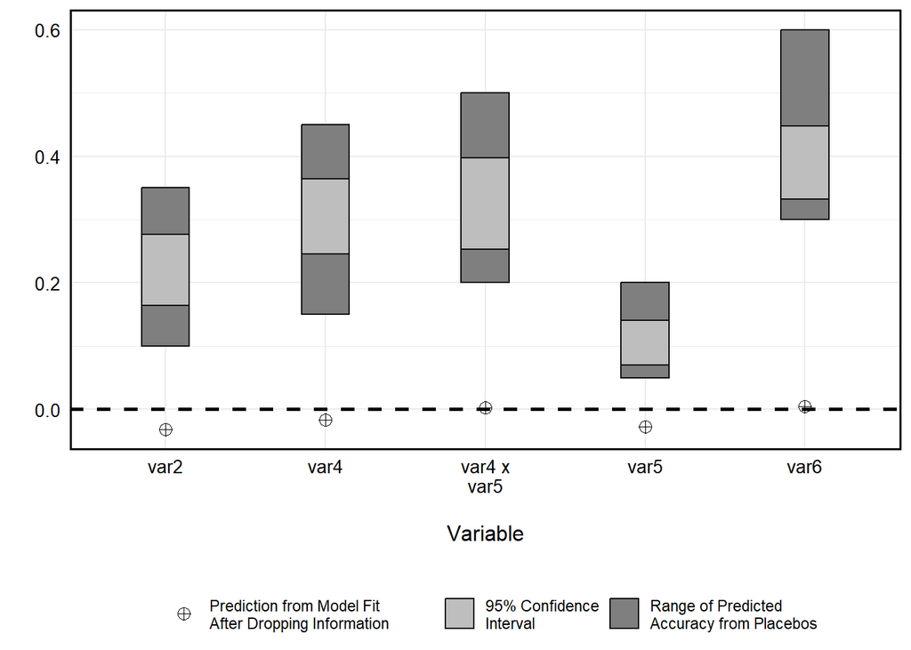

```r
pai_diagnostic_retrieval(output = pai_test,
                         diagnostic = 'placebo',
                         type = 'figure')
```

##### **Push Protocol**

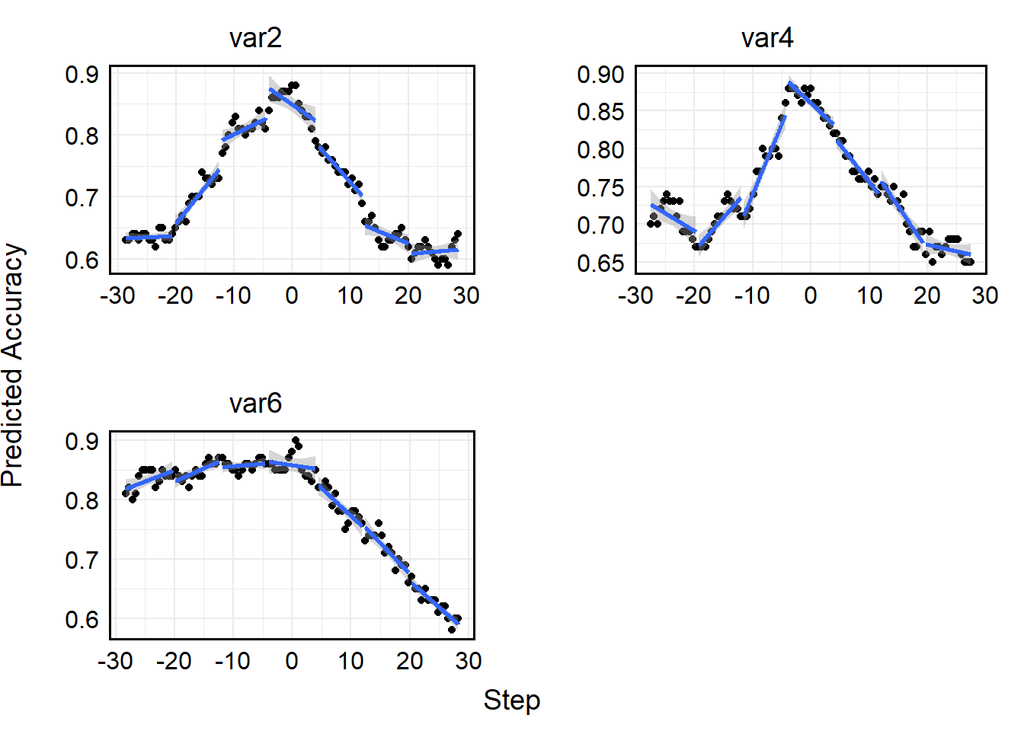

```r
pai_diagnostic_retrieval(output = pai_test,
                         diagnostic = 'push',
                         type = 'figure',
                         combine_plots = TRUE,
                         variables = c('var2', 'var4', 'var6'))
```

*Note*: Output subset to `var2`, `var4`, and `var6`.

##### **Bootstrap Distribution**

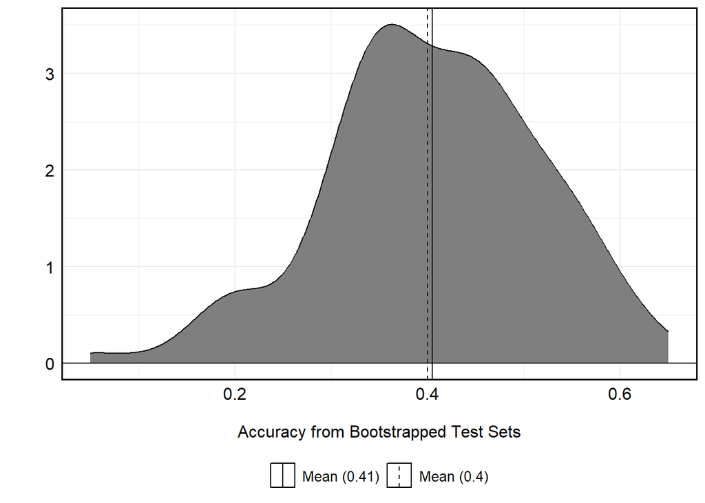

```r
pai_diagnostic_retrieval(output = pai_test,
                         diagnostic = 'bootstrap',
                         type = 'distribution',
                         combine_plots = TRUE)
```

##### **Bootstrap Variable-Level**

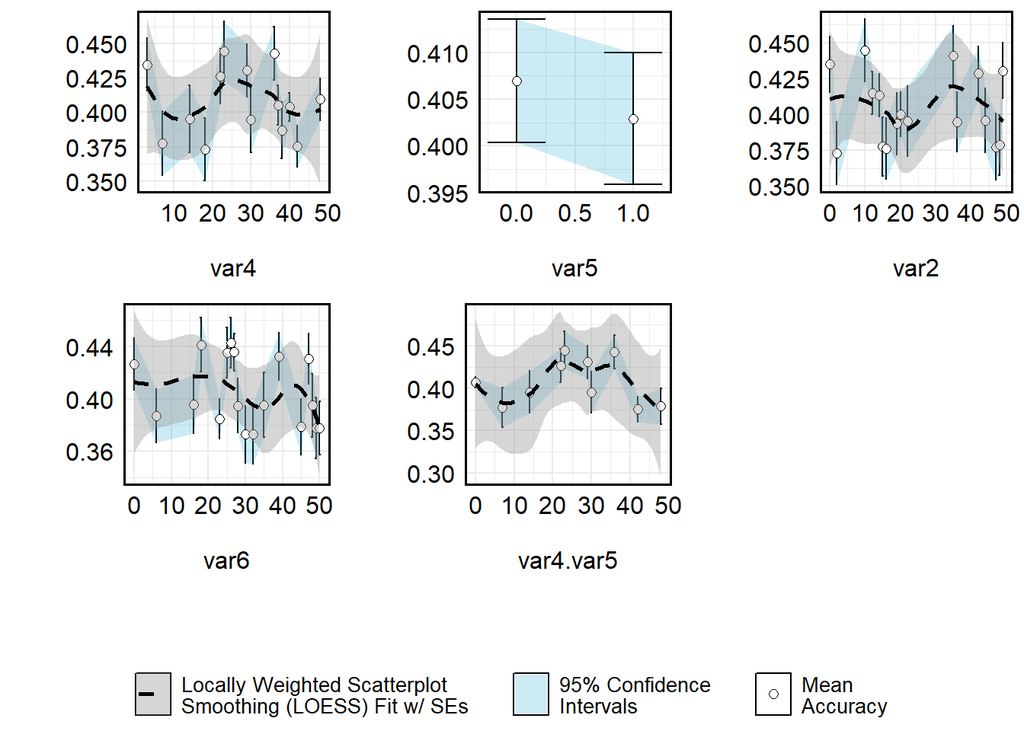

```r
pai_diagnostic_retrieval(output = pai_test,
                         diagnostic = 'bootstrap',
                         type = 'figure',
                         combine_plots = TRUE)
```